# Turkey Terrorism Statistics

19 December 2017

## Group Project

This presentation was prepared for group project of Fall 2017 MEF University, BDA 503-Essentials of Data Analysis course.

Group members are;

1. [Bilge Uzuner](https://mef-bda503.github.io/pj-uzunerb/)
2. [Sefa Erbas](https://mef-bda503.github.io/pj-erbass/)
3. [Türkan Sevgili](https://mef-bda503.github.io/pj-sevgilit/)

## GTD Dataset

The Global Terrorism Database includes information on terrorist events around the World (205 countries, more than 33000 cities, from 1970 through 2016 on at least 45 variables for each case, with more recent incidents including information on more than 120 variables.

- *Geography:* Worldwide
- *Time period:* 1970-2016, except 1993
- *Unit of analysis:* Attack
- *Variables:* >100 variables on location, tactics, perpetrators, targets, and outcomes
- *Sources:* Unclassified media articles

You can find the whole report https://mef-bda503.github.io/gpj-datING_/GTD/GTD_Final.html

## Objectives

- The purpose of the analysis is to understand the Turkey's Terorism Statistics on the basis of the cities, districts, dates, seasons etc.
- Try to define the factors that influence the terror attacks in Turkey.
- A clear understanding of the data to see if we can locate useful insights about where and when terror attacks occur in Turkey.
- To create an opinion on the relatively risky and secure regions based on past experience, by in-depth analysis of the terrorist attacks in Turkey, also to see relatively safe and risky periods during the year.

## Data

The data set that will use in this project and initial exploratory data analysis on it consists of 4,106 observations and 27 variables.

```
## Observations: 4,106
## Variables: 27
## $ eventid        <dbl> 197004250001, 197008310001, 197010020002, 19701...
## $ year           <int> 1970, 1970, 1970, 1970, 1970, 1970, 1970, 1970,...
## $ month          <int> 4, 8, 10, 10, 10, 10, 10, 11, 11, 11, 12, 12, 1...
## $ day            <int> 25, 31, 2, 3, 3, 6, 27, 10, 21, 23, 24, 29, 7, ...
## $ country_code   <int> 209, 209, 209, 209, 209, 209, 209, 209, 209, 20...
## $ country_name   <fctr> Turkey, Turkey, Turkey, Turkey, Turkey, Turkey...
## $ region_code    <int> 10, 10, 10, 10, 10, 10, 10, 10, 10, 10, 10, 10,...
## $ region_name    <fctr> Middle East & North Africa, Middle East & Nort...
## $ provstate      <fctr> Istanbul, Ankara, Izmir, Ankara, Ankara, Ankar...
## $ city           <fctr> Istanbul, Ankara, Izmir, Ankara, Ankara, Ankar...
## $ latitude       <dbl> 41.01484, 39.91839, 38.42371, 39.91839, 39.9183...
## $ longitude      <dbl> 28.96141, 32.86560, 27.13421, 32.86560, 32.8656...
## $ location       <fctr> , , , , , , , , , , , , , , , , , , , , , , , ,
## $ success        <int> 1, 1, 1, 1, 1, 0, 1, 1, 1, 1, 0, 0, 1, 1, 0, 1,...
## $ attacktype1    <fctr> Bombing/Explosion, Bombing/Explosion, Bombing/...
## $ attacktype2    <fctr> , , , , , , , , , , , , , , , , , , , , , , , ,
## $ attacktype3    <fctr> , , , , , , , , , , , , , , , , , , , , , , , ,
## $ targtype1      <fctr> Airports & Aircraft, Military, Military, Gover...
## $ targsubtype1   <fctr> Airline Officer/Personnel, Military Unit/Patro...
## $ weaptype1      <fctr> Explosives/Bombs/Dynamite, Explosives/Bombs/Dy...
## $ weapsubtype1   <fctr> Unknown Explosive Type, Unknown Explosive Type...
## $ property       <int> 1, 1, 1, 1, 1, 1, 1, 1, 1, 1, 1, 0, 1, 1, 0, 1,...
## $ propextent_txt <fctr> , , , , , , , , , Minor (likely < $1 million),...
## $ propvalue      <dbl> NA, NA, NA, NA, NA, NA, NA, NA, NA, 25000, NA, ...
## $ gname          <fctr> Palestinians, Turkish People's Liberation Army...
## $ nkill          <int> 0, 0, 0, NA, 0, 0, 0, 0, 0, NA, 0, 0, 0, NA, 0,...
## $ nwound         <int> 0, 0, 0, NA, 0, 0, 0, 0, 0, NA, 0, 1, 0, NA, 0,...
```

## Terrorist Attacks, 1970-2016 (Global vs Turkey)

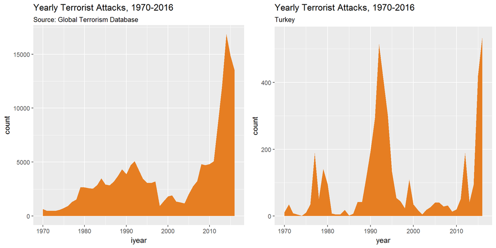

## Histogram of Attacks by Year

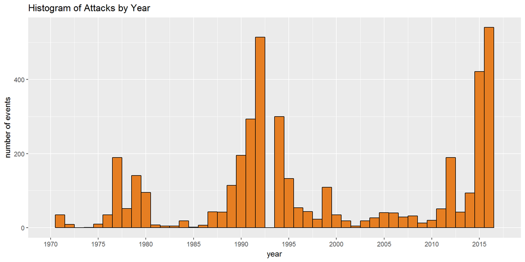

## Histogram of Attacks by Month

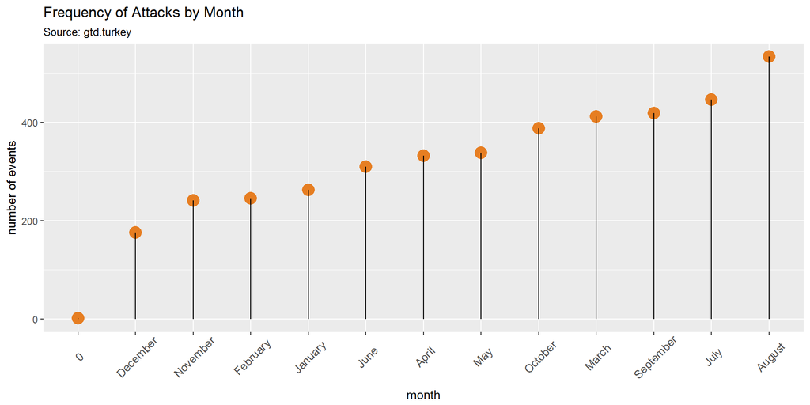

## Frequency of Attacks by City

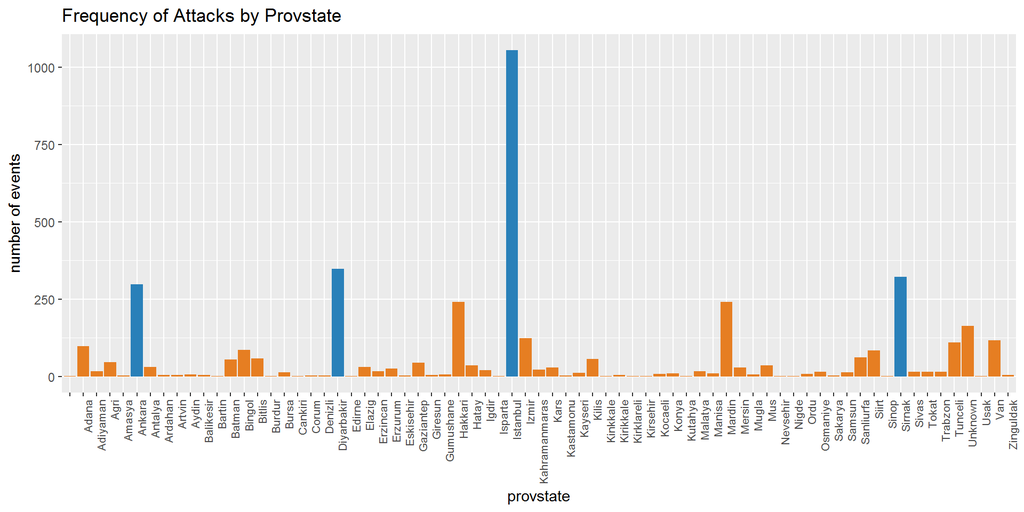

## Dot Plot of Attacks by City

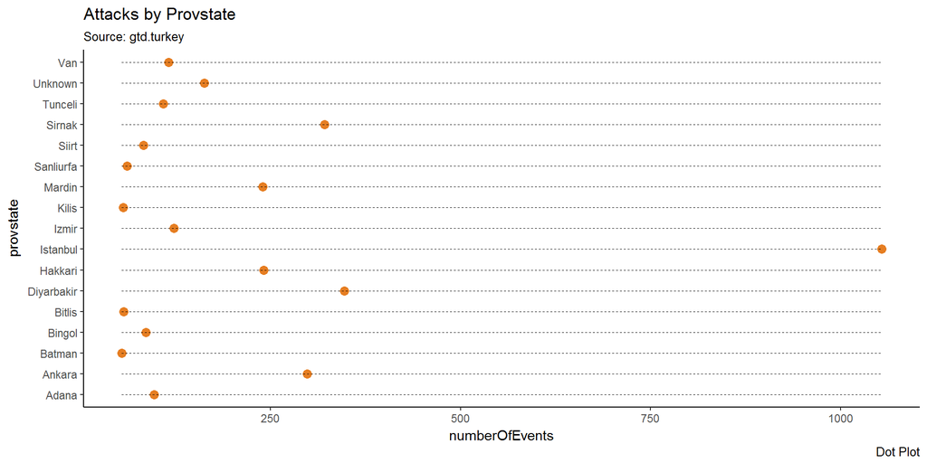

## Success/Failure Rates

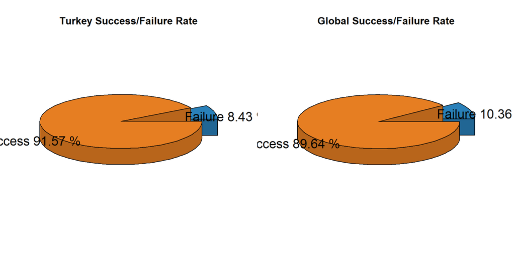

## Frequency of Attacks by Attacktype

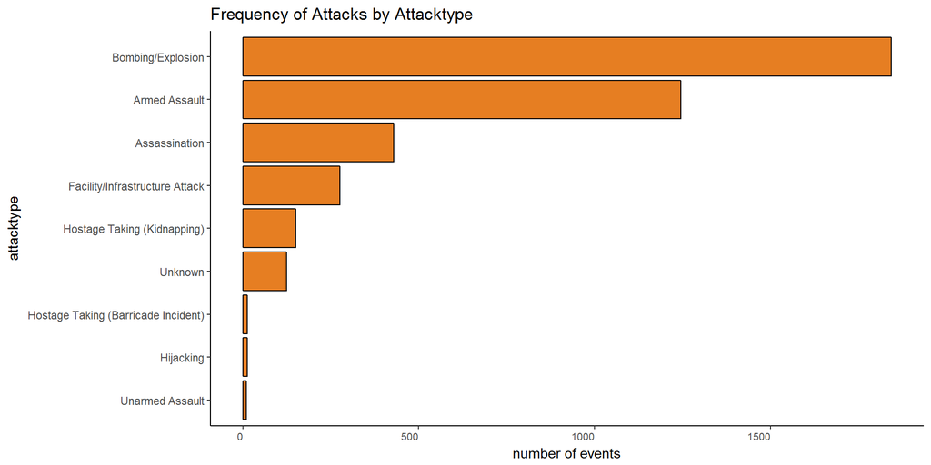

## Frequency of Attacks by Target type

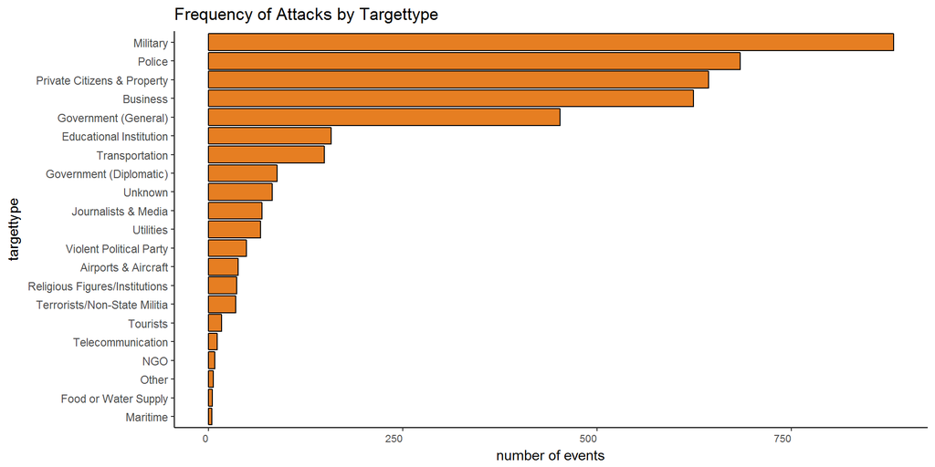

## Frequency of Attacks by Weapon type

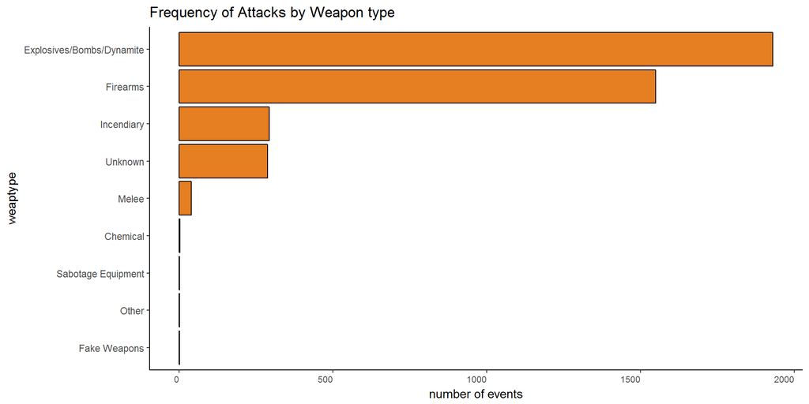

## Frequency of Group Name

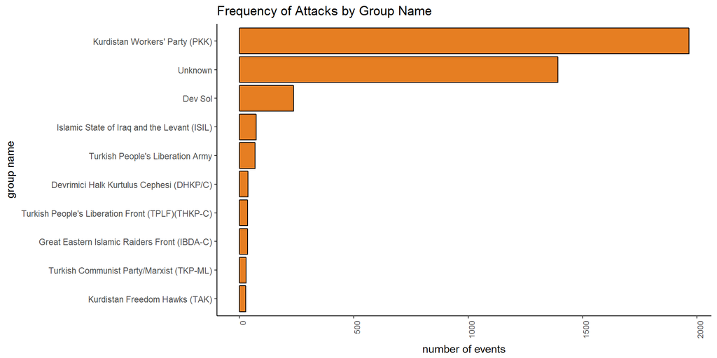

## Attacks by Terrorist Groups in last two years

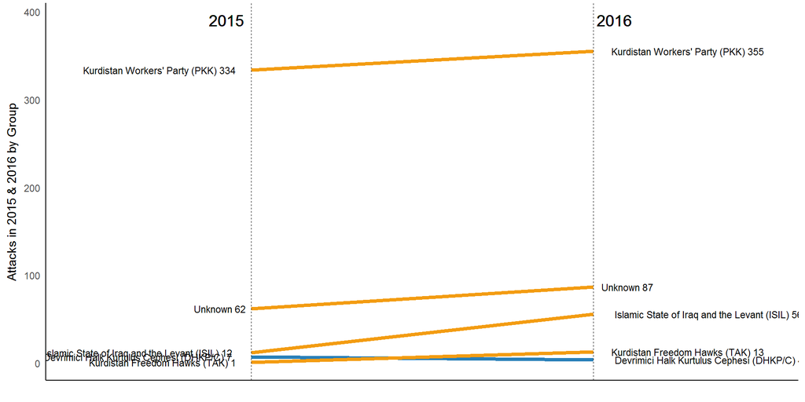

## Attacks vs Casualities

[figure not shown]

## Killed vs Wounded Rate

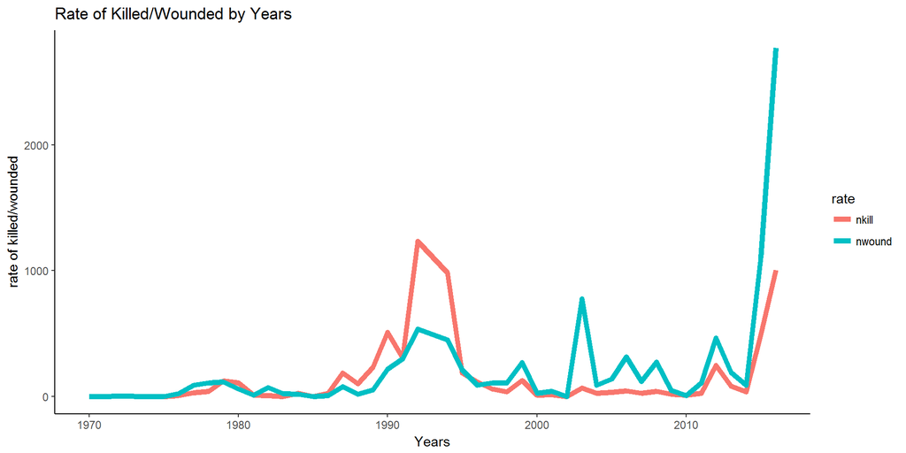

## Group Name vs Number of Kill

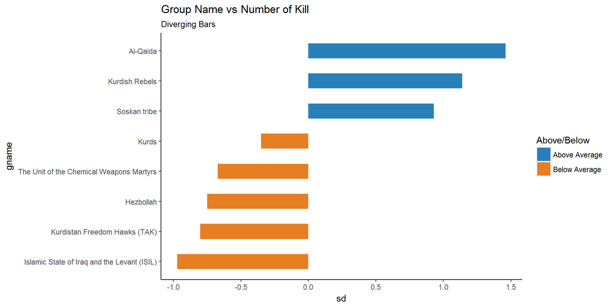

## Yearly terrorist attacks by Attack type

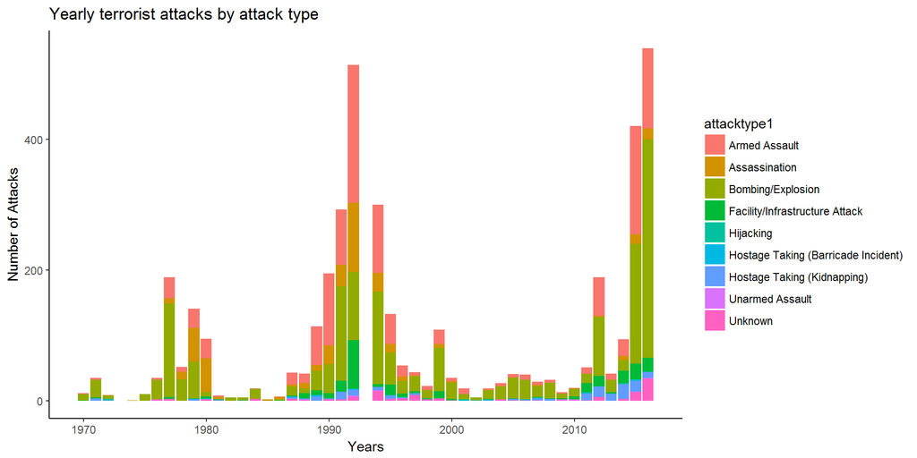

## Terrorist attacks in Turkey by attack type

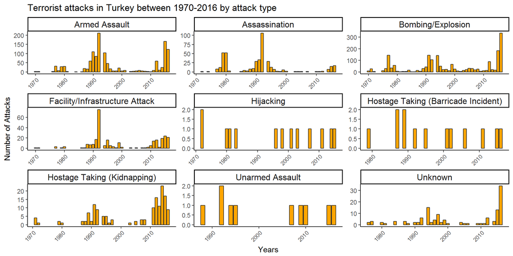

## Causalities in Turkey by attack type

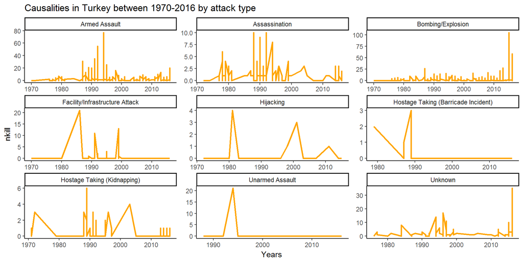

## Group Name vs Target Type

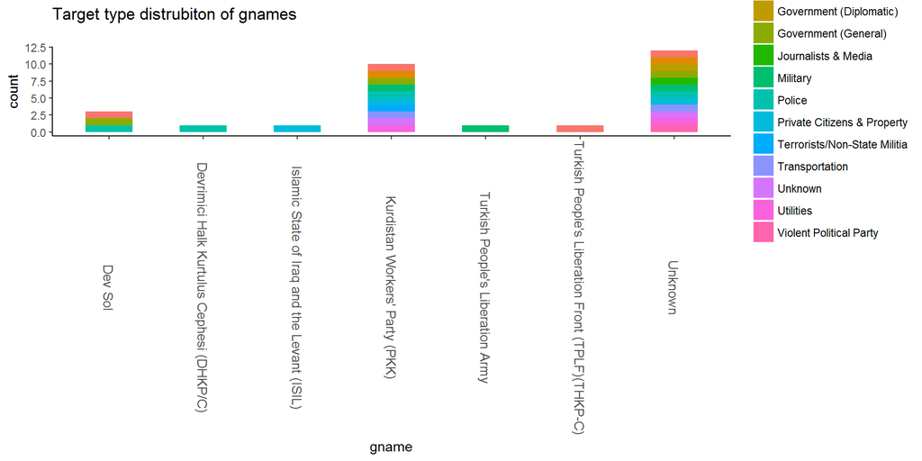

## Yearly terrorist attacks by Weapon type

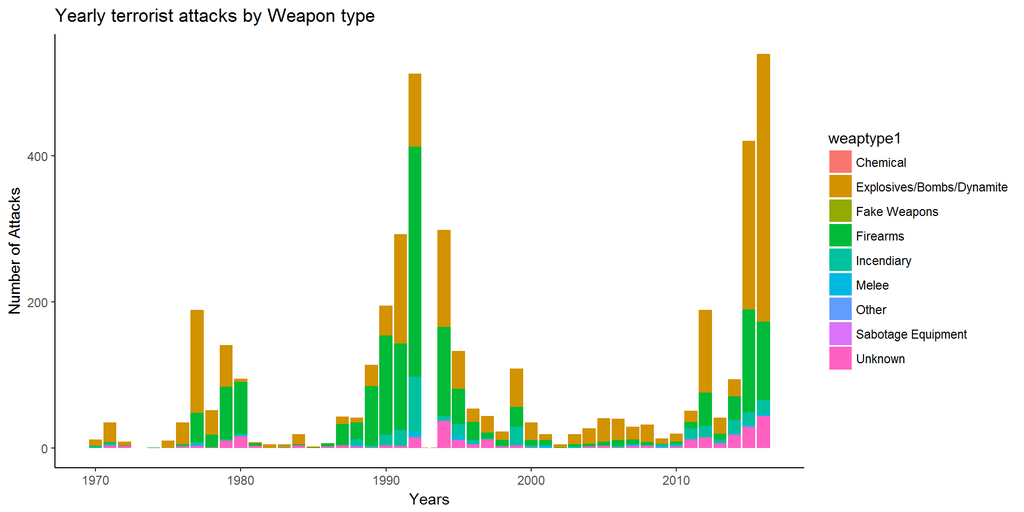

## Wordcloud Analysis

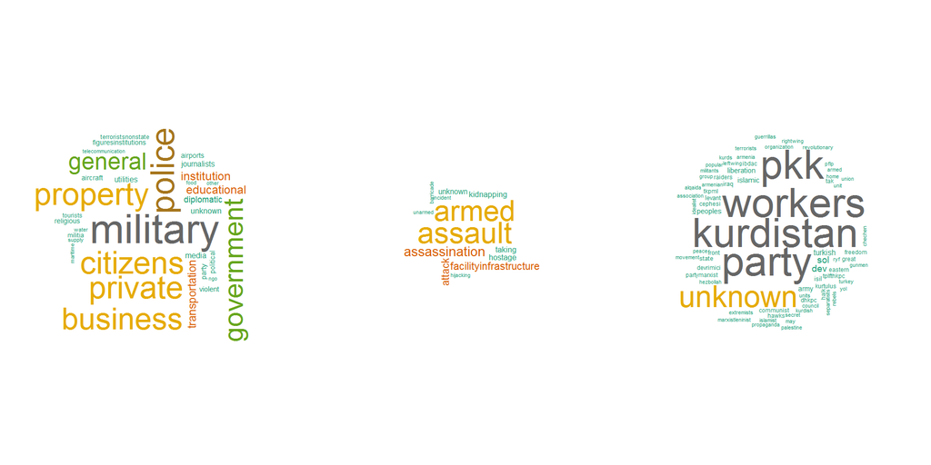

## Analysis on Map

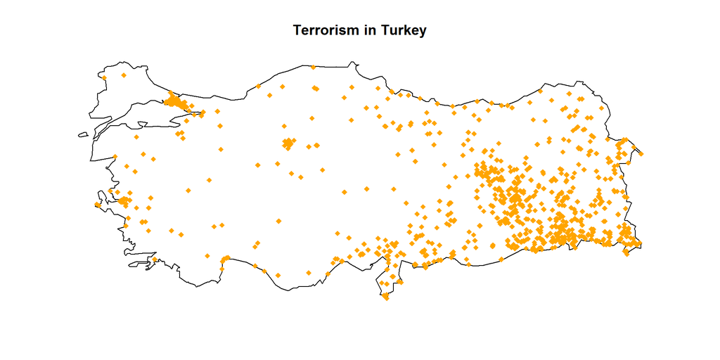

Also we can create interactive data map with Shiny module.https://sevgilit.shinyapps.io/GTD_Shiny/

## What are the most used weapons?

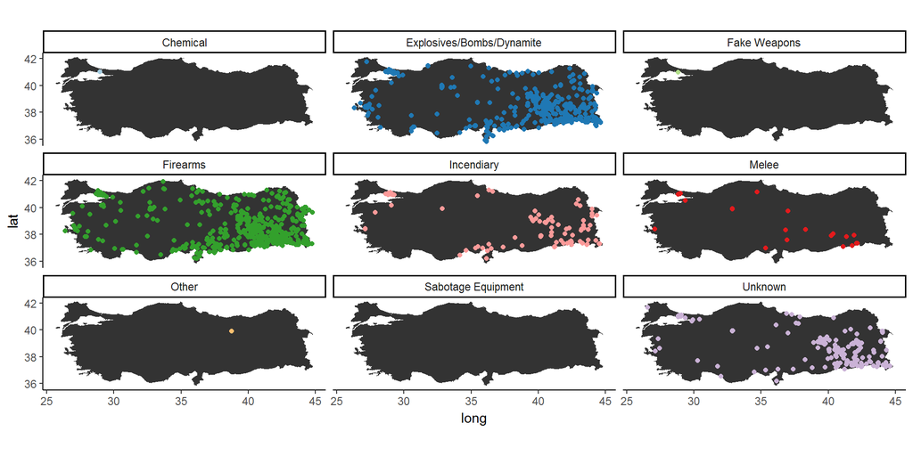

[figure not shown]